# Networks Hw 2

A closer look at Enrons Emails

Peter Sullivan  
2022-02-09

#### Looking at Nodes and Edges:

```r
ls()
```

```
[1] "network_edgelist" "network_igraph"   "network_statnet"
```

```r
vcount(network_igraph)
```

```
[1] 184
```

```r
ecount(network_igraph)
```

```
[1] 125409
```

```r
print(network_statnet)
```

```
 Network attributes:
  vertices = 184
  directed = TRUE
  hyper = FALSE
  loops = FALSE
  multiple = FALSE
  bipartite = FALSE
  total edges= 3010
    missing edges= 0
    non-missing edges= 3010

 Vertex attribute names:
    vertex.names

 Edge attribute names not shown
```

```r
#print(network_igraph)
```

It looks like the igraph and statnet variables are showing different edges. The network igraph is showing 184 nodes and 125409 edges. The network statnet is showing 184 nodes, and 3010 edges.

#### Weighted, Directed, Single Mode Network?

```r
is_bipartite(network_igraph)
```

```
[1] FALSE
```

```r
is_directed(network_igraph)
```

```
[1] TRUE
```

```r
is_weighted(network_igraph)
```

```
[1] FALSE
```

Using the Network Igraph set, we have a single mode network, which is directed, and is not weighted.

#### Looking at Vertex and Edge Attributes:

```r
vertex_attr_names(network_igraph)
```

```
[1] "Email" "Name"  "Note"
```

```r
network::list.vertex.attributes(network_statnet)
```

```
[1] "na"           "vertex.names"
```

```r
edge_attr_names(network_igraph)
```

```
[1] "Time"      "Reciptype" "Topic"     "LDC_topic"
```

```r
network::list.edge.attributes(network_statnet)
```

```
[1] "LDC_topic"      "LDC_topic_desc" "LDC_topic_name"
[4] "na"             "Reciptype"      "Time"
[7] "Topic"
```

Igraph Attribute Names: Email, Name, Note

Igraph edge names: Time, Reciptype, Topic, LDC_topic

Statnet attribute names: na, vertex.names

statnet edge names: LDC_topic, LDC_topic_desc, LDC_topic_name, na, Reciptype, Time, Topic

#### Accessing Attribute DATA:

```r
V(network_igraph)$Name %>% head()
```

```
[1] "Albert Meyers"    "Thomas Martin"    "Andrea Ring"
[4] "Andrew Lewis"     "Andy Zipper"      "Jeffrey Shankman"
```

```r
V(network_igraph)$Email %>% head()
```

```
[1] "albert.meyers" "a..martin"     "andrea.ring"   "andrew.lewis"
[5] "andy.zipper"   "a..shankman"
```

```r
V(network_igraph)$Note %>% head()
```

```
[1] "Employee, Specialist"         "Vice President"
[3] "NA"                           "Director"
[5] "Vice President, Enron Online" "President, Enron Global Mkts"
```

```r
(network_igraph)$Carrier %>% head()
```

```r
head(network_statnet %v% "vertex.names")
```

```
[1] 1 2 3 4 5 6
```

```r
head(network_statnet %e% "Time")
```

```
[1] "1979-12-31 21:00:00" "1979-12-31 21:00:00" "1979-12-31 21:00:00"
[4] "1979-12-31 21:00:00" "1979-12-31 21:00:00" "1979-12-31 21:00:00"
```

```r
head(network_statnet %e% "LDC_topic")
```

```
[1] "-1" "-1" "-1" "-1" "-1" "-1"
```

#### Summarizing Attribute DATA

```r
summary(E(network_igraph)$Time)
```

```
   Length     Class      Mode
   125409 character character
```

```r
summary(network_statnet %e% "Distance")
```

```
Length  Class   Mode
     0   NULL   NULL
```

#### Dyad Census

```r
igraph::dyad.census(network_igraph)
```

```
$mut
[1] 30600

$asym
[1] 64208

$null
[1] -77972
```

```r
sna::dyad.census(network_statnet)
```

```
     Mut Asym  Null
[1,] 913 1184 14739
```

The dyad census for null using igraph is coming up -77,972. This seems wrong.

#### Triad Census

```r
igraph::triad.census(network_igraph)
```

```
 [1] 700234  19530 249694   8409   2695   5176   7060  13227   1180
[10]     59   6781   1023   1137    786   2782   1611
```

```r
sna::triad.census(network_statnet)
```

```
        003    012    102 021D 021U 021C 111D  111U 030T 030C  201
[1,] 700234 150250 118974 8409 2695 5176 7060 13227 1180   59 6781
     120D 120U 120C  210  300
[1,] 1023 1137  786 2782 1611
```

#### Transitivity

```r
transitivity(network_igraph)
```

```
[1] 0.3725138
```

```r
gtrans(network_statnet)
```

```
[1] 0.3580924
```

```r
transitivity(network_igraph, type = "global")
```

```
[1] 0.3725138
```

```r
transitivity(network_igraph, type = "average")
```

```
[1] 0.5055302
```

```r
transitivity(network_igraph, type = "local") %>% head()
```

```
[1] 0.0023288309 0.0013788877 0.0008393993 0.0031740105 0.0007847921
[6] 0.0017129438
```

The transitivity for igraph and statnet data sets were pretty close.

The global transitivity is .3725 while the average transitivity is higher at .5. This means that actors with fewer connections will have higher transitivity. This could be due to overweighted groups or this could be similar to different departments that know a lot of people in their department, but do not know others in the other departments.

#### Local Transitivity

```r
Names <- V(network_igraph)$Name
Names %>% head()
```

```
[1] "Albert Meyers"    "Thomas Martin"    "Andrea Ring"
[4] "Andrew Lewis"     "Andy Zipper"      "Jeffrey Shankman"
```

```r
Local_transivity <- transitivity(network_igraph, type = "local")

transitivity_tibble <- tibble(Names = Names, Local_transivity = Local_transivity)

transitivity_tibble %>% arrange(desc(Local_transivity))
```

```
# A tibble: 184 x 2
   Names            Local_transivity
   <chr>                       <dbl>
 1 Thomas Martin             0.0571
 2 Joe Quenet                0.0179
 3 Mark Haedicke             0.0159
 4 Kim Ward                  0.0157
 5 Peter Keavey              0.0146
 6 Monika Causholli          0.0134
 7 David Delainey            0.00917
 8 Susan Pereira             0.00909
 9 Larry Campbell            0.00810
10 NA                        0.00641
# ... with 174 more rows
```

```r
gtrans(network_statnet)
```

```
[1] 0.3580924
```

#### Distances in the Network

```r
#distances(network_igraph, "Thomas Martin","Andrea Ring")



average.path.length(network_igraph)
```

```
[1] 2.390464
```

```r
average.path.length(network_igraph, directed = F)
```

```
[1] 2.085787
```

I took these vertex names, so I’m a bit confused why these are not showing up correctly.

#### Identifying Isolates

```r
igraph::components(network_igraph)
```

```
$membership
  [1] 1 1 1 1 1 1 1 1 1 1 1 1 1 1 1 1 1 1 1 1 1 1 1 1 1 1 1 1 1 1 1 1
 [33] 1 1 1 1 1 1 1 1 1 1 1 1 1 1 1 1 1 1 1 1 1 1 1 1 1 1 1 1 1 1 1 1
 [65] 1 1 1 1 1 1 1 2 1 1 1 1 1 1 1 1 1 1 1 1 1 1 1 1 1 1 1 1 1 1 1 1
 [97] 1 1 1 1 1 1 1 1 1 1 1 1 1 1 1 1 1 1 1 1 1 3 1 1 1 1 1 1 1 1 1 1
[129] 1 1 1 1 1 1 1 1 1 1 1 1 1 1 1 1 1 1 1 1 1 1 1 1 1 1 1 1 1 1 1 1
[161] 1 1 1 1 1 1 1 1 1 1 1 1 1 1 1 1 1 1 1 1 1 1 1 1

$csize
[1] 182   1   1

$no
[1] 3
```

```r
#Isolates
isolates(network_statnet)
```

```
[1]  72 118
```

```r
as.vector(network_statnet %v% "vertex.names")[c(isolates(network_statnet))]
```

```
[1]  72 118
```

For some reason it seems that Network statnet vertex.names is only showing numbers, not actually the names. I wonder if the statnet was set up incorrectly.

There are two isolates.

#### Density

```r
graph.density(network_igraph)
```

```
[1] 3.72443
```

```r
network.density(network_statnet)
```

```
[1] 0.08939178
```

```r
graph.density(network_igraph, loops = TRUE)
```

```
[1] 3.704188
```

```r
gden(network_statnet, diag = FALSE)
```

```
[1] 0.08939178
```

The Igraph density is over 1, and the network density is around 9%. Very different densities.

#### Vertex Degrees

```r
igraph::degree(network_igraph) %>% head()
```

```
[1] 114 428 391 104 957 381
```

```r
sna::degree(network_statnet) %>% head()
```

```
[1] 10 32 21  9 59 30
```

There is a significant difference between degrees from the igraph dataset compared to the statnet data.

```r
network_degree <- data.frame(Name = V(network_igraph)$Name,
                             degree = igraph::degree(network_igraph, loops =FALSE))
network_degree %>% arrange(desc(degree)) %>% slice(1:10)
```

```
              Name degree
1    Jeff Dasovich  13967
2    James Steffes   9404
3       Tana Jones   9307
4  Richard Shapiro   8994
5               NA   6591
6      Steven Kean   6384
7    John Lavorato   6177
8  Michael Grigsby   5860
9      Mark Taylor   5693
10  Louise Kitchen   5362
```

Jeff Dasovich has the highest number of degrees around 13K. He must be very high up in the company.

#### Degree in Directed Networks

```r
sna::degree(network_statnet, cmode = "indegree")%>% head()
```

```
[1]  4 21 10  6 30 17
```

```r
sna::degree(network_statnet, cmode = "outdegree") %>% head()
```

```
[1]  6 11 11  3 29 13
```

```r
igraph::degree(network_igraph, mode ="in", loops = FALSE) %>% head()
```

```
[1]  78 334 224  88 614 210
```

```r
igraph::degree(network_igraph, mode ="out", loops = FALSE)%>%head()
```

```
[1]  36  92 167  16 325 169
```

```r
Degree_network <- data.frame(Name = V(network_igraph)$Name,
           total_degrees = igraph::degree(network_igraph, loops = FALSE),
           in_degree = igraph::degree(network_igraph, mode ="in", loops = FALSE),
           out_degree = igraph::degree(network_igraph, mode ="out", loops = FALSE) ) %>% arrange(desc(total_degrees))

Degree_network %>% slice(1:10)
```

```
              Name total_degrees in_degree out_degree
1    Jeff Dasovich         13967      2612      11355
2    James Steffes          9404      4988       4416
3       Tana Jones          9307      2268       7039
4  Richard Shapiro          8994      6893       2101
5               NA          6591      2698       3893
6      Steven Kean          6384      2676       3708
7    John Lavorato          6177      3352       2825
8  Michael Grigsby          5860      1097       4763
9      Mark Taylor          5693      3694       1999
10  Louise Kitchen          5362      2087       3275
```

#### Summary Statistics

```r
summary(Degree_network)
```

```
     Name           total_degrees       in_degree
 Length:184         Min.   :    0.0   Min.   :   0.0
 Class :character   1st Qu.:  212.8   1st Qu.: 150.5
 Mode  :character   Median :  512.5   Median : 314.0
                    Mean   : 1184.0   Mean   : 592.0
                    3rd Qu.: 1401.2   3rd Qu.: 655.2
                    Max.   :13967.0   Max.   :6893.0
   out_degree
 Min.   :    0.00
 1st Qu.:   30.75
 Median :  159.00
 Mean   :  591.99
 3rd Qu.:  600.50
 Max.   :11355.00
```

#### Degree Distribution

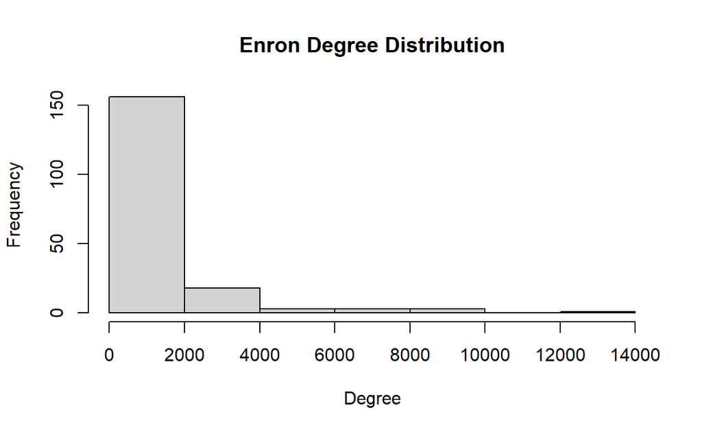

```r
hist(Degree_network$total_degrees, main = "Enron Degree Distribution", xlab = "Degree")
```

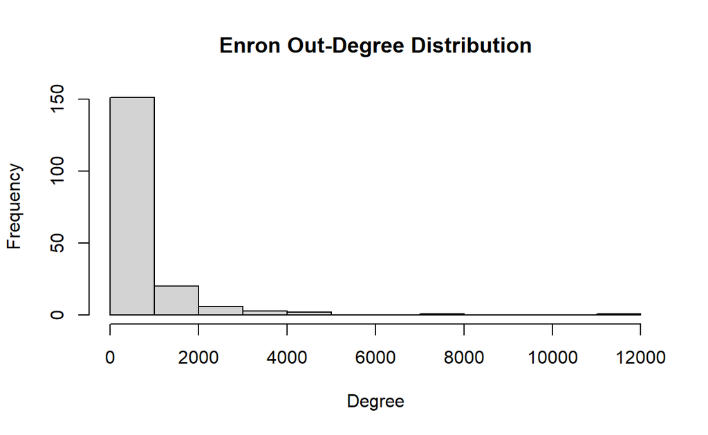

```r
hist(Degree_network$out_degree, main ="Enron Out-Degree Distribution", xlab = "Degree")
```

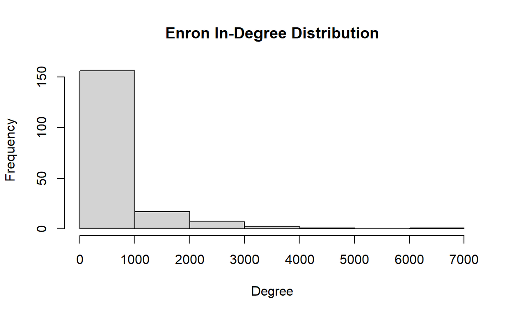

```r
hist(Degree_network$in_degree, main = "Enron In-Degree Distribution", xlab = "Degree")
```

Most people in the company have limited number of degrees of connections, while their are a select few with many connections.

#### Network Degree Centralization

```r
#centralization(network_statnet, degree, cmode= "indegree")
#centralization(network_statnet, degree, cmode = "outdegree")


centr_degree(network_igraph, loops = FALSE, mode = "in")$centralization
```

```
[1] 34.61991
```

```r
centr_degree(network_igraph, loops = FALSE, mode = "out")$centralization
```

```
[1] 59.13566
```

There is a higher centralization for out-degree nodes compared to in-degree nodes.